# Project 6460 RNA study QC Report

Team 113 - David Adam’s lab

25 April 2024

**Report version: 0.1.6**

# 1 Project information

The data files and project information provided used in the following report are the following:

- **Study ID:** 6460
- **Samples submitted file:** 6460-samples.txt
- **QC metrics file:** 6460-bmetrics.txt
- **TPMs table file:** 6460-htseq-tpm.txt
- **Total number of samples submitted for sequencing:** 50
- **Total number of samples with sequencing data:** 50
- **Total number of samples that failed sequencing:** 0

The RNA samples for this study were prepared using standard Illumina protocols for RNAseq processing of stranded paired end multiplexed libraries. Libraries were pooled and sequenced across **2** **sequencing lanes** on the **Illumina Novaseq 6000** sequencing machine.

# 2 Sequencing QC metrics

## 2.1 Thresholds used in to FLAG potential issues

| Name | Level | Source Tool | Flag Threshold | Notes |
| --- | --- | --- | --- | --- |
| *reads_assigned* | SAMPLE | HTSEQCOUNT | <20,000,000 | The number of htseqcounts reads that aligned to a single gene lie. the sum of the count column) |
| *alignment_not_unique* | SAMPLE | HTSEQCOUNT | > n_reads_assigned | The number of htseqcounts reads that aligned to non-unique genome locations |
| *ambiguous* | SAMPLE | HTSEQCOUNT | > n_reads_assigned | The number of htseqcounts reads that matched to more than one gene |
| *no_feature* | SAMPLE | HTSEQCOUNT | > n_reads_assigned | The number of htseqcounts reads that uniquely aligned but did not intersect a gene |
| *not_aligned* | SAMPLE | HTSEQCOUNT | > n_reads_assigned | The number of htseqcounts reads that did not align |
| *too_low_aQual* | SAMPLE | HTSEQCOUNT | > n_reads_assigned | The number of htseqcounts reads rejected for MAPQ<1O |
| base_mismatch_ratio | SAMPLE | RNASEQC | >0.75% | The total number of mismatched bases (as determined by the ’NM" tag) of all “Mapped Reads” divided by the total aligned length of all “Mapped Reads”. |
| *genes* | SAMPLE | RNASEQC | <10,000 | The number of genes which had at least 5 unambiguous reads |
| *efficiency* | SAMPLE | RNASEQC | <40% | The proportion of “Exonic Reads” out of all reads which were not Secondary Alignments or Platform/Vendor QC Failing reads |
| exonic_rate | SAMPLE | RNASEQC | <50% | The proportion of “Mapped Reads” for which all aligned segments unambiguously aligned to exons of the same gene |
| intergenic_rate | SAMPLE | RNASEQC | >25% | The proportion of “Mapped Reads” (above) for which none of the aligned segments intersected any genes |
| *3prime_bias* | SAMPLE | RNASEQC | <0.3 or >0.5 | A gene with even coverage in both it’s3’ and 5’ windows would have a bias of 0.5; bias near 1 or 0 may indicate degredation |
| *rRNA_rate* | SAMPLE | RNASEQC | >2.5% | The proportion of “Mapped Reads” which at least partially intersected with an annotated rRNA gene |
| coverage | SAMPLE | RNASEQC | <1 % | Transcript coverage is computed by dropping the first and last 500bp of each gene and measuring the “HighQuality” coverage over the remainder of the gene |

## 2.2 Total number of reads

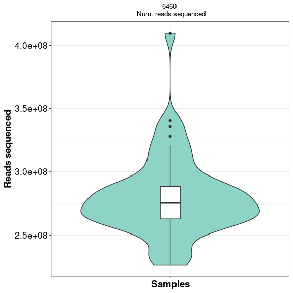

```r
######### Violin plot for - sequenced reads
sqr.col<-RColorBrewer::brewer.pal(n=12, name="Set3")[1]
viol_seqr<- ggplot(reshape2::melt(bmet, id.vars="sample", measure.vars="reads_total"), aes(x=variable, y=value))+
  geom_violin(aes(fill=variable))+
  # scale_fill_manual(values = "lightblue")+ # to fill the violing plot
  scale_fill_manual(values = sqr.col)+
  ggtitle(paste(study_ID, "\n Num. reads sequenced"))+
  theme_bw()+
  theme(
    axis.text.x=element_blank(),
    axis.text.y=element_text(colour="Black",size =13),
    axis.title.x=element_text(face="bold", size=14),
    axis.title.y=element_text(face="bold", size=14),
    legend.position = "none",
    plot.title = element_text(hjust = 0.5, size = 10))+
  ylab("Reads sequenced")+
  xlab("Samples")+
  geom_boxplot(width=0.1)
  # geom_dotplot(binaxis='y', stackdir='center', dotsize=0.4)

# TO CONTRol the plot
knitr::opts_chunk$set( collapse = TRUE, comment = "#>", fig.align = 'center',  fig.height = 8,
  fig.width = 6 )
 viol_seqr
```

# 3 Transcriptome QC analysis

Reads were mapped using **STAR v2.5.0c** against the **GRCh38 human reference genome with the ERCC spike-in sequences** and **ENSEMBL v103** gene annotation. To assess expressions reads were counted using [**HTSeq-count v0.7.2**](https://htseq.readthedocs.io/en/release_0.11.1/count.html) its **“union”** counting mode (see [here](https://htseq.readthedocs.io/en/release_0.11.1/_images/count_modes.png)) and appropriate stranded parameters. Finally, read counts were transformed to transcripts per million (**TPM**).

## 3.1 Counted read pairs QC

For RNAseq expression assessment sequencing depth is an important factor to be able to assess expression reliably. We recommend to exclude samples with low number of read pairs (fragments) counted **<20 Million reads counted**. This would allow a reliable assessment of highly expressed genes (see **[Tarazona, S. *et. al.* 2011](https://genome.cshlp.org/content/21/12/2213.full)** ).

In addition to the counted read pairs, there are some adjunct special counters from [here](https://htseq.readthedocs.io/en/release_0.11.1/count.html)

- **no_feature:** reads (or read pairs) which could not be assigned to any feature (set S as described above was empty).
- **ambiguous:** reads (or read pairs) which could have been assigned to more than one feature and hence were not counted for any of these, unless the –nonunique all option was used (set S had more than one element).
- **too_low_aQual:** reads (or read pairs) which were skipped due to the -a option, see below
- **not_aligned:** reads (or read pairs) in the SAM file without alignment
- **alignment_not_unique:** reads (or read pairs) with more than one reported alignment. These reads are recognized from the NH optional SAM field tag. (If the aligner does not set this field, multiply aligned reads will be counted multiple times, unless they get filtered out by due to the -a option.) Note that if the –nonunique all option was used, these reads (or read pairs) are still assigned to features.

## 3.2 QC metrics used to determine passed or fail samples

The metrics used to pass or fail samples for transcriptome assessment were the following :

**reads_assigned, alignment_not_unique, ambiguous, no_feature, not_aligned, too_low_aQual, detected_genes, efficiency, 3prime_bias, rRNA_rate**

```r
# To calculate the number of failed samples  use the threshholds
# reads_assigned, alignment_not_unique, ambiguous, no_feature, not_aligned, too_low_aQual, detected_genes_ok, efficiency, 3prime_bias, rRNA_rate

#Get logical variables
bmet$reads_assigned_ok<- as.logical(bmet$reads_assigned_ok)
bmet$alignment_not_unique_ok<- as.logical(bmet$alignment_not_unique_ok)
bmet$ambiguous_ok<- as.logical(bmet$ambiguous_ok)
bmet$no_feature_ok<- as.logical(bmet$no_feature_ok)
bmet$not_aligned_ok<- as.logical(bmet$not_aligned_ok)
bmet$too_low_aQual_ok<- as.logical(bmet$too_low_aQual_ok)
bmet$detected_genes_ok<- as.logical(bmet$detected_genes_ok)
bmet$efficiency_ok<- as.logical(bmet$efficiency_ok)
bmet$threeprime_bias_ok<- as.logical(bmet$threeprime_bias_ok)
bmet$rrna_rate_ok<- as.logical(bmet$rrna_rate_ok)


true_pass<-(((((((((bmet$reads_assigned_ok & bmet$alignment_not_unique_ok) &
  bmet$ambiguous_ok ) &
  bmet$no_feature_ok) &
  bmet$not_aligned_ok ) &
  bmet$too_low_aQual_ok ) &
  bmet$detected_genes_ok ) &
  bmet$efficiency_ok ) &
  bmet$threeprime_bias_ok ) &
  bmet$rrna_rate_ok )

bmet$true_pass<-true_pass
rm(true_pass)
```

### 3.2.1 Total number of samples recommended for subsequent transcriptomic analysis

Summary of the number of passing samples (based on the suggested cutoff above):

- **Total num. samples:** 50
- **Total num. of passing samples:** 50
- **Total num. samples to remove** 0
- **Approval percentage** 100 %

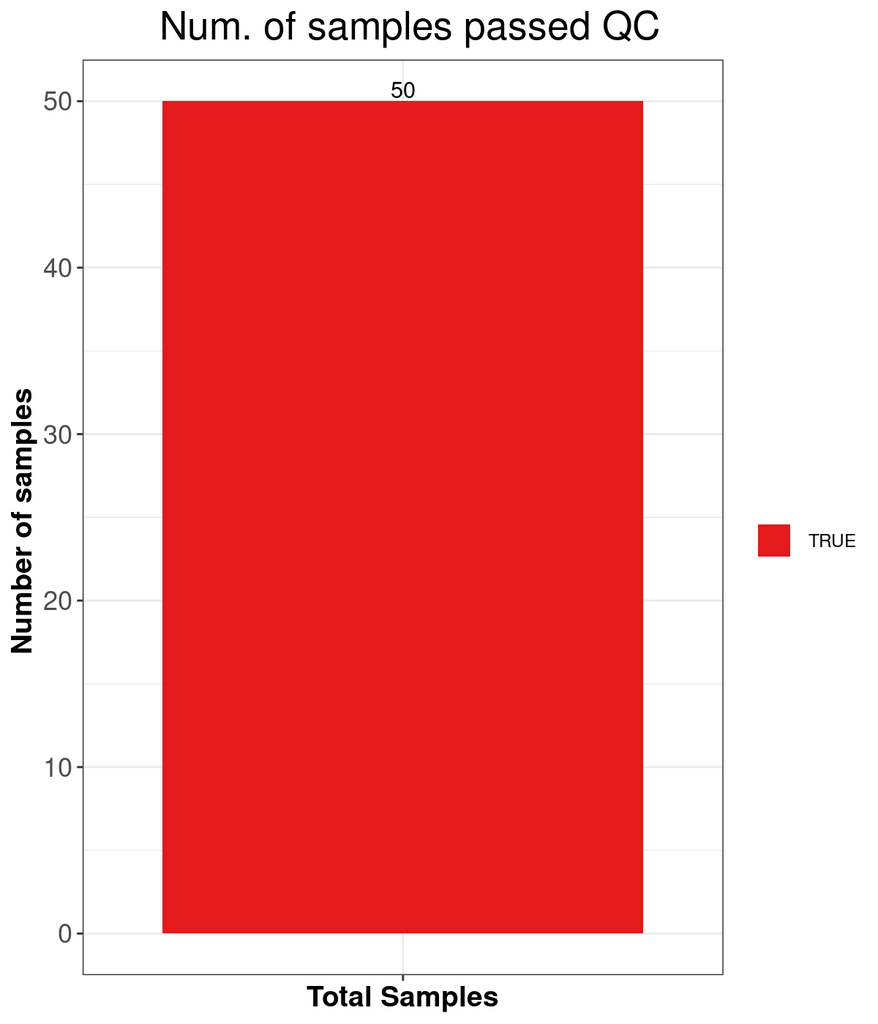

```r
######### Bar plots showing - PASS FAIL for all QC trheshholds
testtab<-reshape2::melt(bmet[,c("sample","true_pass")], id.vars=c("sample"), measure.vars="true_pass")
testtab$value<- as.logical(testtab$value)

pass_bplot<-ggplot(data=testtab, aes(x=value, fill=value))+
    geom_bar(stat = "count",  position = "stack")+
    theme_bw()+
    scale_fill_brewer(type="qual",palette = "Set1"  )+
    ggtitle(paste("Num. of samples passed QC "))+
    # ylab(paste0("Number of samples ", study_ID))+
    ylab(paste0("Number of samples "))+
    # xlab(paste0( study_ID, " Total Samples N=", nsamples))+
    xlab(paste0( " Total Samples "))+
    # ylim(0,70)+
    theme( axis.text.x = element_blank(),
           axis.title.x = element_text(face="bold", size = 14),
           axis.title.y = element_text(face="bold", size = 14),
           plot.title = element_text(hjust = 0.6),
           strip.text.y= element_text(size = 8,face="bold"),
           strip.text.x= element_text(size = 13),
           title =element_text(size = 16),
           axis.text.y = element_text( size = 13))+
    guides(fill = guide_legend(title = ""))+
    geom_text(aes(label =after_stat(count)),stat = "count", vjust = -0.2, colour = "black")
    # facet_grid(variable  ~ studyid+fplate   , switch = "y")


# TO CONTRol the plot
# knitr::opts_chunk$set( collapse = TRUE, comment = "#>", fig.align = 'left',
#                         fig.height=round(40+(dim(coverage)[1]*0.2)),
#                         fig.width = 15 )
                        # fig.height=round(200+(dim(coverage)[1]*10)),
                        # fig.width = 1000 )

pass_bplot
```

### 3.2.2 Total read pairs counted per sample

Summary of reads counted by sample

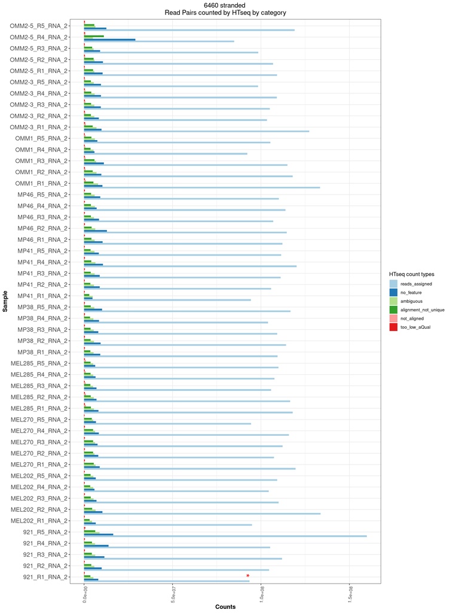

### 3.2.3 QC metrics table

|  | sample | type | n_runs | runs | pass | reads_total | reads_assigned | detected_genes | mapped_rRNA_rate | base_mismatch_ratio | efficiency | exonic_rate | intergenic_rate | three_prime_bias_median | transcript_coverage_median | alignment_not_unique | ambiguous | no_feature | not_aligned | too_low_aQual | reads_assigned_ok | base_mismatch_ratio_ok | detected_genes_ok | efficiency_ok | exonic_rate_ok | intergenic_rate_ok | rrna_rate_ok | threeprime_bias_ok | coverage_ok | … |
| --- | --- | --- | --- | --- | --- | --- | --- | --- | --- | --- | --- | --- | --- | --- | --- | --- | --- | --- | --- | --- | --- | --- | --- | --- | --- | --- | --- | --- | --- | --- |
| 1 | 921_R1_RNA_2 | RNA | 2 | 48779_3#19;48779_4#19 | true | 235534005 | 93477923 | 20091 | 0.0067 | 0.0023 | 0.8405 | 0.8523 | 0.0352 | 0.3639 | 0.8226 | 3572224 | 5270312 | 8019745 | 293898 | 409025 | True | true | True | True | true | true | True | True | true | … |
| 2 | 921_R2_RNA_2 | RNA | 2 | 48779_3#20;48779_4#20 | true | 265052188 | 104655514 | 20557 | 0.006 | 0.0022 | 0.8376 | 0.8486 | 0.0454 | 0.3689 | 0.9577 | 4038386 | 5792578 | 9951589 | 269771 | 440419 | True | true | True | True | true | true | True | True | true | … |
| 3 | 921_R3_RNA_2 | RNA | 2 | 48779_3#21;48779_4#21 | true | 285635481 | 111893966 | 20866 | 0.0061 | 0.0022 | 0.8266 | 0.8377 | 0.0455 | 0.369 | 1.0812 | 4344968 | 6272546 | 11536134 | 302682 | 493900 | True | true | True | True | true | true | True | True | true | … |
| 4 | 921_R4_RNA_2 | RNA | 2 | 48779_3#22;48779_4#22 | true | 278649680 | 105202015 | 21036 | 0.0096 | 0.0025 | 0.7916 | 0.8034 | 0.0432 | 0.3952 | 1.1194 | 4452970 | 6161528 | 13791014 | 262225 | 541837 | True | true | True | True | true | true | True | True | true | … |
| 5 | 921_R5_RNA_2 | RNA | 2 | 48779_3#23;48779_4#23 | true | 409987856 | 159882362 | 21378 | 0.0063 | 0.0023 | 0.8238 | 0.836 | 0.0318 | 0.3766 | 1.5523 | 6292961 | 8780903 | 16470367 | 471121 | 730054 | True | true | True | True | true | true | True | True | true | … |
| 6 | MEL202_R1_RNA_2 | RNA | 2 | 48779_3#29;48779_4#29 | true | 230597465 | 94919692 | 20083 | 0.0095 | 0.0022 | 0.8669 | 0.876 | 0.0331 | 0.3425 | 0.8936 | 3157699 | 4606691 | 6629814 | 152015 | 372063 | True | true | True | True | true | true | True | True | true | … |
| 7 | MEL202_R2_RNA_2 | RNA | 2 | 48779_3#30;48779_4#30 | true | 328080400 | 133666970 | 20873 | 0.0108 | 0.0022 | 0.8616 | 0.8712 | 0.042 | 0.3435 | 1.2521 | 4582607 | 6489901 | 10379079 | 218859 | 525997 | True | true | True | True | true | true | True | True | true | … |
| 8 | MEL202_R3_RNA_2 | RNA | 2 | 48779_3#31;48779_4#31 | true | 266859563 | 109968134 | 20305 | 0.0101 | 0.0023 | 0.8737 | 0.8835 | 0.0333 | 0.3434 | 1 | 3725763 | 5375853 | 7019962 | 171935 | 462601 | True | true | True | True | true | true | True | True | true | … |
| 9 | MEL202_R4_RNA_2 | RNA | 2 | 48779_3#32;48779_4#32 | true | 251229755 | 104446529 | 20075 | 0.0124 | 0.0023 | 0.8777 | 0.8873 | 0.0231 | 0.3333 | 0.9243 | 3476956 | 5151389 | 5921644 | 169292 | 449437 | True | true | True | True | true | true | True | True | true | … |
| 10 | MEL202_R5_RNA_2 | RNA | 2 | 48779_3#33;48779_4#33 | true | 263689022 | 109158165 | 20174 | 0.0095 | 0.0023 | 0.8763 | 0.8859 | 0.0294 | 0.3432 | 0.976 | 3647756 | 5279828 | 6627972 | 176453 | 428606 | True | true | True | True | true | true | True | True | true | … |

[output cut: 40 more lines]

## 3.3 TPM clustering of the samples

### 3.3.1 Hierarchichal clustering of samples

To assess the presence of potential batch effects we calculate the Pearson correlation coefficient for all the possible paired comparissons across all the samples in the study based on all the genes’ expression in TPMs. Subsequently we performed a hierarchical clustering based on the pearson correlations obtained.

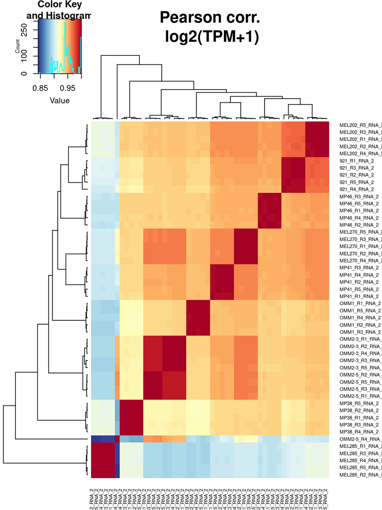

```r
# #    3.1 Genehumane the HEATMAP for the Pearson correlation comparison of all sample based on TPMs  ------------------
x<-tpms
#Calculate the LOG2
x<-log2(x+1)
#Calculate the pearson Correlation coefficient
xc<-cor(x)
hmcolors<-colorRampPalette(rev(brewer.pal(n=11,name = "RdYlBu" )))(60)

knitr::opts_chunk$set( collapse = TRUE, comment = "#>", fig.align = 'left',  fig.height = 30, fig.width = 30, out.width = "100%" )

if(length(bmet$sample)>100){
  cexparam<-0.30
} else {
  cexparam<-0.55
}

#GET the heatmap
heatmap.2(xc, col=hmcolors, , main="Pearson corr.\n log2(TPM+1)",
          key=TRUE, keysize=1.25,  cexCol=cexparam, cexRow=cexparam, trace="none", margins=c(3,5),)
```

### 3.3.2 Hierarchichal clustering of samples with QC status labels

Hierarchical clustering performed over the pearson correlation coefficients from all the pairwise comparisons across all the samples sequenced across the studies with plates affected, showing the QC status of the sample at the top.

```r
#Define the Experimental group colours
Passed_QC=c(brewer.pal(n=12, name="Paired")[c(4,9)] )[1:length(unique(bmet$true_pass))]
names(Passed_QC)<-unique(bmet$true_pass)
group_cols<- list(Passed_QC=Passed_QC)

#Defina the Heatmap annotation
ha<- ComplexHeatmap::HeatmapAnnotation(Passed_QC=bmet$true_pass,
                       col = group_cols)

ComplexHeatmap::Heatmap(t(xc), name = "Pearson_corr",
        top_annotation = ha,
        col = hmcolors,
        row_dend_width = unit(30, "mm"),
        column_dend_height = unit(30, "mm"),
        column_names_gp = gpar(fontsize=10),
        row_names_gp = gpar(fontsize=10),
        width =15, height = 10
        )
```

[figure not shown]

### 3.3.3 Hierarchichal clustering of samples with QC status labels and Run_laneID

Hierarchical clustering performed over the pearson correlation coefficients from all the pairwise comparisons across all the samples sequenced across the studies with plates affected, showing the QC status of the sample at the top.

```r
#Define the Experimental group colours
Passed_QC=c(brewer.pal(n=12, name="Paired")[c(4,9)] )[1:length(unique(bmet$true_pass))]
names(Passed_QC)<-unique(bmet$true_pass)

#Define the runlane ID colours
if(length(unique(bmet$Run_laneID))<=3){
  Run_laneID=c(brewer.pal(n=length(unique(bmet$Run_laneID)), name="Set3") )[1:length(unique(bmet$Run_laneID))]
} else{
  Run_laneID=brewer.pal(n=length(unique(bmet$Run_laneID)), name="Set3")
}
```

```r
names(Run_laneID)<-unique(bmet$Run_laneID)
group_cols<- list(Passed_QC=Passed_QC,
                  Run_laneID=Run_laneID)

#Defina the Heatmap annotation
ha<- ComplexHeatmap::HeatmapAnnotation(Passed_QC=bmet$true_pass,
                       Run_laneID=bmet$Run_laneID,
                       col = group_cols)

ComplexHeatmap::Heatmap(t(xc), name = "Pearson_corr",
        top_annotation = ha,
        col = hmcolors,
        row_dend_width = unit(30, "mm"),
        column_dend_height = unit(30, "mm"),
        column_names_gp = gpar(fontsize=10),
        row_names_gp = gpar(fontsize=10),
        width =15, height = 10
        )
```

[figure not shown]